# Data 621 Homework #1

#### Michael Ippolito’s code on residuals. Feel free to keep it remvove it as per the next steps

Define function to look at residuals.

```r
# ResidualAnalysis <- function(lmod) { # Plot residuals
# plot(lmod) # Shapiro test # The null hypothesis is that
# the residuals are normal.  # If the p-value is small,
# reject the null (i.e., the residuals are not normal).  st
# <- shapiro.test(lmod$residuals) if (st$p.value <= 0.05) {
# print(paste0('The p-value of ', st$p.value, ' is <= 0.05,
# so reject the null; i.e., the residuals are NOT
# normal.')) } else { print(paste0('The p-value of ',
# st$p.value, ' is > 0.05, so do not reject the null; i.e.,
# the residuals are normal.')) } }
```

#### Residual Analysis

Look at residuals.

```r
# Residual analysis ResidualAnalysis(lm)
```

$~$

### **Model Building**

$~$

##### **Model 1 - Full Model**

By testing all variables in this first model we are able to see how significant are the variables in our dataset. We will then be able to use this model to base our other models.

```r
# model 1
m1 <- lm(TARGET_WINS ~ ., data = baseball_df_final, na.action = na.omit)

# we can use one summary function not both summary(m1)
summ(m1)
```

| Observations | 2276 |
| --- | --- |
| Dependent variable | TARGET_WINS |
| Type | OLS linear regression |

| F(13,2262) | 68.45 |
| --- | --- |
| R² | 0.28 |
| Adj. R² | 0.28 |

|  | Est. | S.E. | t val. | p |
| --- | --- | --- | --- | --- |
| (Intercept) | 10.06 | 5.47 | 1.84 | 0.07 |
| INDEX | -0.00 | 0.00 | -1.48 | 0.14 |
| TEAM_BATTING_H | 0.03 | 0.00 | 9.09 | 0.00 |
| TEAM_BATTING_2B | -0.01 | 0.01 | -1.07 | 0.28 |
| TEAM_BATTING_3B | 0.10 | 0.02 | 5.42 | 0.00 |
| TEAM_BATTING_HR | 0.11 | 0.03 | 4.10 | 0.00 |
| TEAM_BATTING_BB | 0.04 | 0.00 | 9.21 | 0.00 |
| TEAM_BATTING_SO | -0.00 | 0.00 | -0.29 | 0.77 |
| TEAM_BASERUN_SB | 0.04 | 0.00 | 10.12 | 0.00 |
| TEAM_PITCHING_H | 0.00 | 0.00 | 1.73 | 0.08 |
| TEAM_PITCHING_HR | -0.05 | 0.02 | -2.08 | 0.04 |
| TEAM_PITCHING_BB | -0.02 | 0.01 | -2.32 | 0.02 |
| TEAM_PITCHING_SO | -0.00 | 0.00 | -0.71 | 0.48 |
| TEAM_FIELDING_E | -0.02 | 0.00 | -6.78 | 0.00 |

Standard errors: OLS

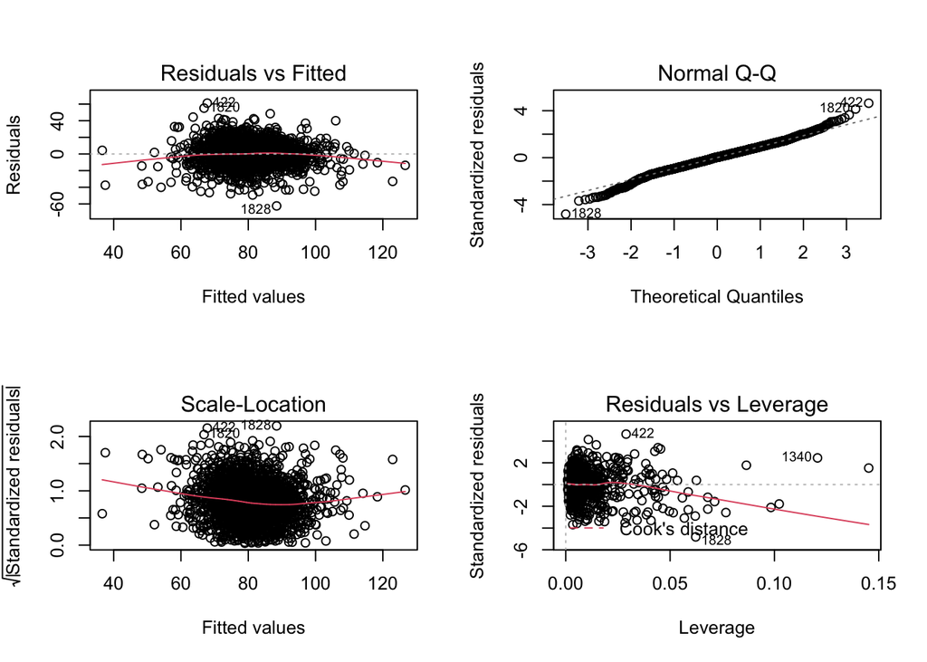

```r
par(mfrow = c(2, 2))
plot(m1)
```

##### **Model 2: Log transformation**

Note: Model 2 was not a successful model compared to model 1. There weren’t any significant changes between the two models therefore discarding this model.

```r
# Checking skewness of dataset
sapply(baseball_df_final, function(x) skewness(x))
```

```
##            INDEX      TARGET_WINS   TEAM_BATTING_H  TEAM_BATTING_2B
##      0.004214942     -0.398723203      1.571333477      0.215101802
##  TEAM_BATTING_3B  TEAM_BATTING_HR  TEAM_BATTING_BB  TEAM_BATTING_SO
##      1.109465188      0.186042144     -1.025759890     -0.234865214
##  TEAM_BASERUN_SB  TEAM_PITCHING_H TEAM_PITCHING_HR TEAM_PITCHING_BB
##      1.896359491      3.349018017      0.287787667     -2.493163443
## TEAM_PITCHING_SO  TEAM_FIELDING_E
##     -0.028260600      2.108419924
```

```r
# Doing log transformations from model 1
baseball_df_final_log <- baseball_df_final

# Applying log transformation for highly skewed variables
baseball_df_final_log$TEAM_BATTING_H <- log10(baseball_df_final_log$TEAM_BATTING_H +
    1)
baseball_df_final_log$TEAM_BATTING_2B <- log10(baseball_df_final_log$TEAM_BATTING_2B +
    1)
baseball_df_final_log$TEAM_PITCHING_H <- log10(baseball_df_final_log$TEAM_PITCHING_H +
    1)
baseball_df_final_log$TEAM_PITCHING_BB <- log10(baseball_df_final_log$TEAM_PITCHING_BB +
    1)
baseball_df_final_log$TEAM_FIELDING_E <- log10(baseball_df_final_log$TEAM_FIELDING_E +
    1)
baseball_df_final_log$TEAM_BASERUN_SB <- log10(baseball_df_final_log$TEAM_BASERUN_SB +
    1)

# Checking skewness
sapply(baseball_df_final_log, function(x) skewness(x))
```

```
##            INDEX      TARGET_WINS   TEAM_BATTING_H  TEAM_BATTING_2B
##      0.004214942     -0.398723203      0.783501655     -0.404123601
##  TEAM_BATTING_3B  TEAM_BATTING_HR  TEAM_BATTING_BB  TEAM_BATTING_SO
##      1.109465188      0.186042144     -1.025759890     -0.234865214
##  TEAM_BASERUN_SB  TEAM_PITCHING_H TEAM_PITCHING_HR TEAM_PITCHING_BB
##     -0.151684218      2.142986416      0.287787667    -13.600156875
## TEAM_PITCHING_SO  TEAM_FIELDING_E
##     -0.028260600      1.087713936
```

```r
# model 2 log
m2 <- lm(TARGET_WINS ~ ., data = baseball_df_final_log, na.action = na.omit)

# we can use one or the other not both summary(m2)
summ(m2)
```

| Observations | 2276 |
| --- | --- |
| Dependent variable | TARGET_WINS |
| Type | OLS linear regression |

| F(13,2262) | 69.93 |
| --- | --- |
| R² | 0.29 |
| Adj. R² | 0.28 |

|  | Est. | S.E. | t val. | p |
| --- | --- | --- | --- | --- |
| (Intercept) | -270.74 | 37.80 | -7.16 | 0.00 |
| INDEX | -0.00 | 0.00 | -1.61 | 0.11 |
| TEAM_BATTING_H | 106.88 | 13.77 | 7.76 | 0.00 |
| TEAM_BATTING_2B | -4.67 | 5.24 | -0.89 | 0.37 |
| TEAM_BATTING_3B | 0.11 | 0.02 | 6.06 | 0.00 |
| TEAM_BATTING_HR | 0.12 | 0.03 | 4.40 | 0.00 |
| TEAM_BATTING_BB | 0.03 | 0.00 | 8.80 | 0.00 |
| TEAM_BATTING_SO | -0.01 | 0.00 | -1.77 | 0.08 |
| TEAM_BASERUN_SB | 13.93 | 1.25 | 11.17 | 0.00 |
| TEAM_PITCHING_H | 5.46 | 5.83 | 0.94 | 0.35 |
| TEAM_PITCHING_HR | -0.05 | 0.02 | -2.24 | 0.02 |
| TEAM_PITCHING_BB | -2.09 | 4.26 | -0.49 | 0.62 |
| TEAM_PITCHING_SO | -0.00 | 0.00 | -0.29 | 0.77 |
| TEAM_FIELDING_E | -16.47 | 2.29 | -7.18 | 0.00 |

Standard errors: OLS

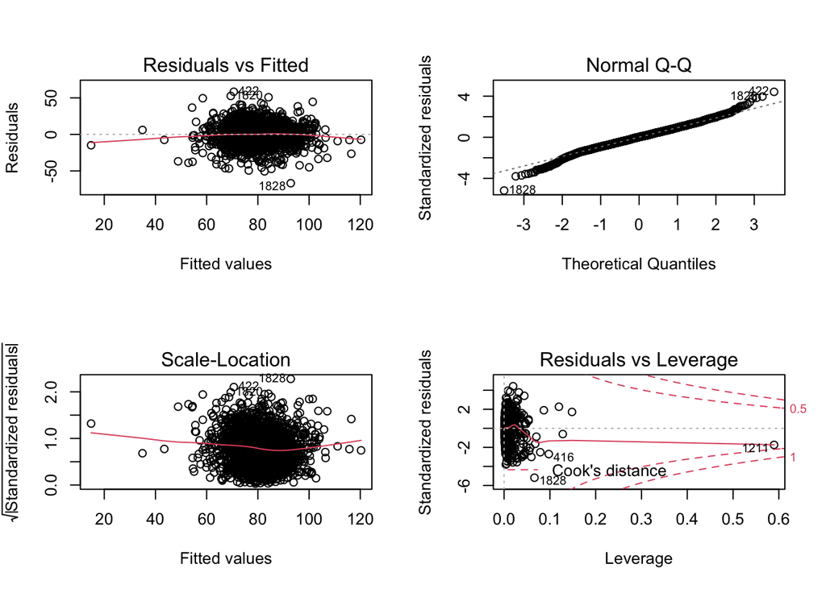

```r
par(mfrow = c(2, 2))
plot(m2)
```

$~$

##### **Model 3: Statistically significant**

Focusing on statistically significant values chosen primarily from their R output.

```r
# model 3
m3 <- lm(TARGET_WINS ~ TEAM_BATTING_H + TEAM_BATTING_3B + TEAM_BATTING_HR +
    TEAM_BATTING_BB + TEAM_BASERUN_SB + TEAM_FIELDING_E, data = baseball_df_final)

# summary(m3)
summ(m3)
```

| Observations | 2276 |
| --- | --- |
| Dependent variable | TARGET_WINS |
| Type | OLS linear regression |

| F(6,2269) | 142.46 |
| --- | --- |
| R² | 0.27 |
| Adj. R² | 0.27 |

|  | Est. | S.E. | t val. | p |
| --- | --- | --- | --- | --- |
| (Intercept) | 2.30 | 3.37 | 0.68 | 0.49 |
| TEAM_BATTING_H | 0.03 | 0.00 | 14.54 | 0.00 |
| TEAM_BATTING_3B | 0.09 | 0.02 | 5.42 | 0.00 |
| TEAM_BATTING_HR | 0.05 | 0.01 | 6.22 | 0.00 |
| TEAM_BATTING_BB | 0.03 | 0.00 | 12.09 | 0.00 |
| TEAM_BASERUN_SB | 0.04 | 0.00 | 10.68 | 0.00 |
| TEAM_FIELDING_E | -0.02 | 0.00 | -6.22 | 0.00 |

Standard errors: OLS

```r
# par(mfrow=c(2,2)) plot(m3)
```

$~$

```r
# model 4
m4 <- lm(TARGET_WINS ~ TEAM_BATTING_2B + TEAM_PITCHING_H + TEAM_PITCHING_HR +
    TEAM_PITCHING_BB + TEAM_PITCHING_SO, data = baseball_df_final)

# summary(m4)
summ(m4)
```

| Observations | 2276 |
| --- | --- |
| Dependent variable | TARGET_WINS |
| Type | OLS linear regression |

| F(5,2270) | 80.46 |
| --- | --- |
| R² | 0.15 |
| Adj. R² | 0.15 |

|  | Est. | S.E. | t val. | p |
| --- | --- | --- | --- | --- |
| (Intercept) | 44.44 | 3.45 | 12.87 | 0.00 |
| TEAM_BATTING_2B | 0.06 | 0.01 | 7.22 | 0.00 |
| TEAM_PITCHING_H | 0.01 | 0.00 | 8.04 | 0.00 |
| TEAM_PITCHING_HR | 0.06 | 0.01 | 8.36 | 0.00 |
| TEAM_PITCHING_BB | 0.03 | 0.01 | 6.06 | 0.00 |
| TEAM_PITCHING_SO | -0.01 | 0.00 | -9.49 | 0.00 |

Standard errors: OLS

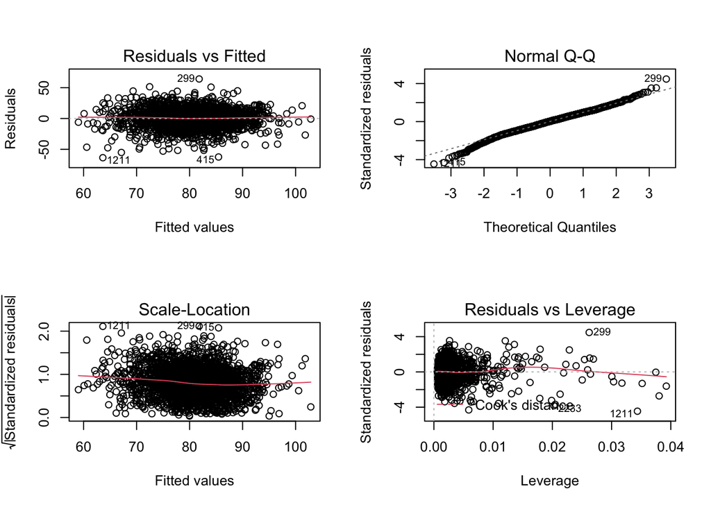

```r
par(mfrow = c(2, 2))
plot(m4)
```

$~$

$~$

### **References**

- https://cran.r-project.org/web/packages/corrplot/vignettes/corrplot-intro.html
- https://r-coder.com/correlation-plot-r/